# Delightful Data Analysis

## Color-Coding Experimental Groups

Consistent visual representation helps spot patterns across multiple plots. Let's assign colors to our experimental groups.

```python
# Generate sample-to-color mapping (3 replicates per group)
sample_groups, color_dictionary = create_group_color_mapping(
    df.columns, group_size=3, return_color_to_group=True
)
sample_groups
```

```
{'2T1_1': '#FF5733',
 '2T1_2': '#FF5733',
 '2T1_3': '#FF5733',
 'SLBP12_1': '#33FF57',
 'SLBP12_2': '#33FF57',
 'SLBP12_3': '#33FF57',
 'SLBP12TET_1': '#3357FF',
 'SLBP12TET_2': '#3357FF',
 'SLBP12TET_3': '#3357FF',
 'SLBP1_1': '#FF33A8',
 'SLBP1_2': '#FF33A8',
 'SLBP1_3': '#FF33A8',
 'SLBP1TET_1': '#33FFF5',
 'SLBP1TET_2': '#33FFF5',
 'SLBP1TET_3': '#33FFF5'}
```

```python
# Customize group labels for clarity
color_dictionary = {
    '#FF5733': '2T1',
    '#33FF57': 'SLBP-12',
    '#3357FF': 'SLBP-12-TET',
    '#FF33A8': 'SLBP-1',
    '#33FFF5': 'SLBP-1-TET'
}
```

## Dimensionality Reduction

Time to explore global patterns! We'll use PCA and MDS to visualize sample relationships in high-dimensional space.

```
Explained variance ratio: [0.64777143 0.08738508 0.07778569 0.05570276 0.03574467]

Variance explained by first 3 principal components:
   component  explained_variance  cumulative_variance
0          1           64.777143            64.777143
1          2            8.738508            73.515651
2          3            7.778569            81.294220
```

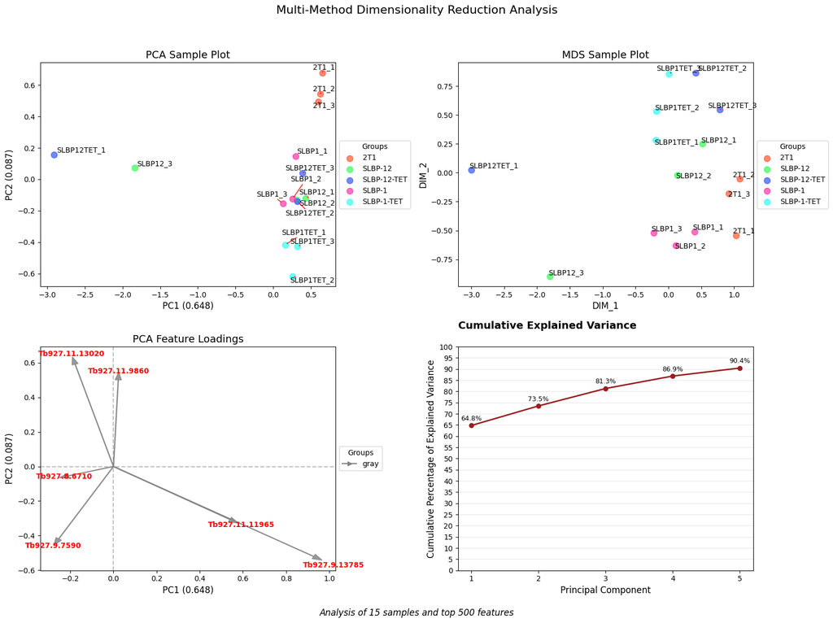

```python
from sklearn.preprocessing import StandardScaler

def preprocess_for_dim_reduction(df):
    """
    Prepare data for dimensionality reduction:
    - Log2 transform (stabilizes variance)
    - Remove remaining missing values
    - Z-score normalization (centers and scales features)
    """
    scaler = StandardScaler()

    # Log transform and clean protein IDs
    processed = np.log2(df).dropna().copy()
    processed.index = [idx.split(':')[0] for idx in processed.index]

    # Standardize features
    processed = pd.DataFrame(
        scaler.fit_transform(processed),
        index=processed.index,
        columns=processed.columns
    )
    return processed

# Generate comprehensive dimensionality reduction dashboard
fig, axes, results_dict = dim_red_utility.create_dim_reduction_dashboard(
    in_df=preprocess_for_dim_reduction(df),
    sample_palette=sample_groups,
    feature_palette={},
    top=500,  # Focus on 500 most variable proteins
    color_dictionary=color_dictionary,
    title="Multi-Method Dimensionality Reduction Analysis"
)

plt.tight_layout(rect=[0, 0.03, 1, 0.95])

# Display variance explained
print("\nVariance explained by first 3 principal components:")
print(results_dict['explained_variance'].head(3))
```

### Critical Finding: Outlier Detection!

These outliers cluster separately from their biological replicates - we need to investigate further!

## Hierarchical Clustering: A Different Perspective

Let's use unsupervised clustering to confirm our outlier observations.

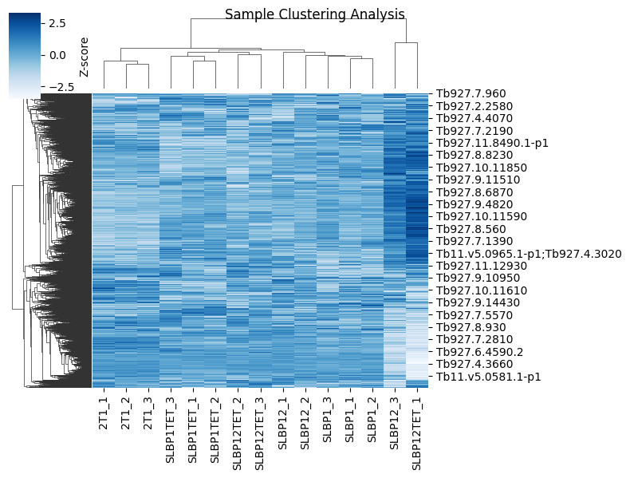

```python
# Generate clustered heatmap with sample dendrograms
sns.clustermap(
    preprocess_for_dim_reduction(df),
    z_score=0,  # Normalize by protein (rows)
    cmap='Blues',
    figsize=(8, 6),
    cbar_kws={'label': 'Z-score'}
)
plt.suptitle('Sample Clustering Analysis', y=0.99)
```

### Root Cause Identified!

Clustering confirms the outliers. After investigating with the MS facility:

- **Problem:** Poor protein recovery during trypsin digestion for these two samples
- **Action:** We want to discard those two samples for differential expression analysis, howewer we will keep them for the sake of simplicity

*Lesson: Always communicate with your core facility when you spot anomalies!*

## Intensity Distribution Assessment

DIA-NN includes built-in normalization, but let's verify intensity distributions are comparable across samples.

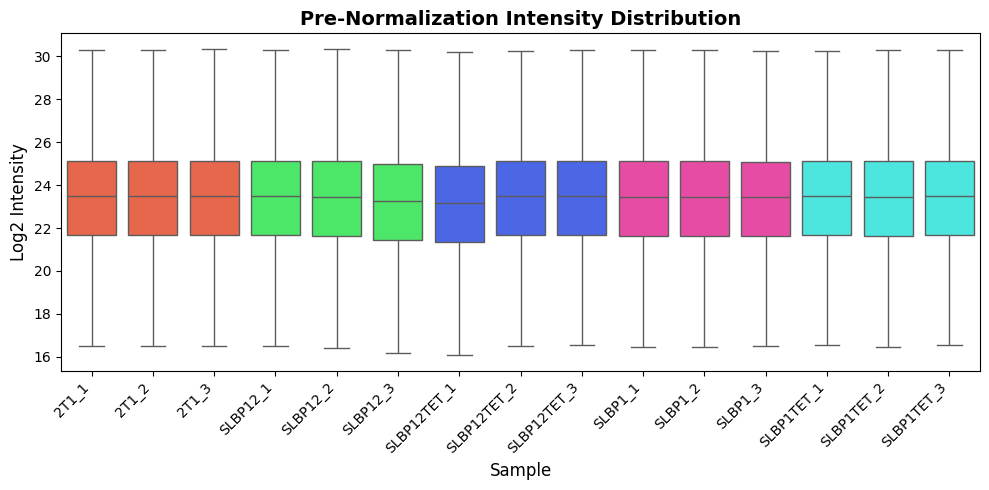

```python
fig, ax = plt.subplots(figsize=(10, 5))

sns.boxplot(
    data=np.log2(df),
    showfliers=False,
    palette=sample_groups.values(),
    ax=ax
)

ax.set_title('Pre-Normalization Intensity Distribution', fontweight='bold', fontsize=14)
ax.set_ylabel('Log2 Intensity', fontsize=12)
ax.set_xlabel('Sample', fontsize=12)
plt.xticks(rotation=45, ha='right')
plt.tight_layout()
plt.show()
```

```
medians [23.48822472 23.49156809 23.49019743 23.47039845 23.46962243 23.27145354
 23.18479772 23.48068322 23.48804703 23.45988983 23.45657874 23.458376
 23.4732135  23.45718642 23.48640297]
target 23.441776005765004
norm_facs [0.99802247 0.99788043 0.99793865 0.99878049 0.99881351 1.00731894
 1.01108391 0.99834301 0.99803002 0.99922788 0.99936893 0.99929236
 0.99866071 0.99934304 0.99809988]
```

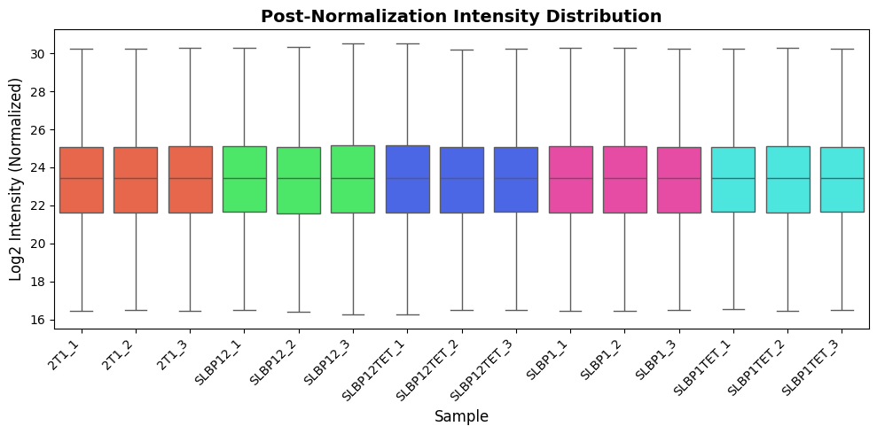

```python
# Apply median normalization for additional balance
data_normalized = norm_loading(np.log2(df))

fig, ax = plt.subplots(figsize=(10, 5))
sns.boxplot(
    data=data_normalized,
    showfliers=False,
    palette=sample_groups.values(),
    ax=ax
)

ax.set_title('Post-Normalization Intensity Distribution', fontweight='bold', fontsize=14)
ax.set_ylabel('Log2 Intensity (Normalized)', fontsize=12)
ax.set_xlabel('Sample', fontsize=12)
plt.xticks(rotation=45, ha='right')
plt.tight_layout()
plt.show()
```

# Validating Knockdown Targets

Let's verify the knockdown efficiency!

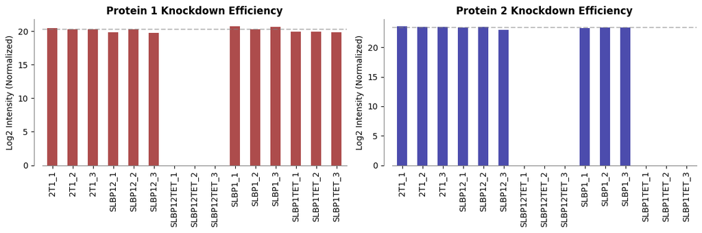

```python
fig, axes = plt.subplots(ncols=2, figsize=(12, 4))

# Protein 1 knockdown
data_normalized.loc['Tb927.3.870:mRNA-p1'].plot(
    kind='bar', ax=axes[0], color='darkred', alpha=0.7
)
axes[0].set_title('Protein 1 Knockdown Efficiency', fontweight='bold')
axes[0].set_ylabel('Log2 Intensity (Normalized)')
axes[0].axhline(y=data_normalized.loc['Tb927.3.870:mRNA-p1'].median(),
                color='gray', linestyle='--', alpha=0.5, label='Median')
clean_axes(axes[0])

# Protein 2 knockdown
data_normalized.loc['Tb927.3.1910:mRNA-p1'].plot(
    kind='bar', ax=axes[1], color='darkblue', alpha=0.7
)
axes[1].set_title('Protein 2 Knockdown Efficiency', fontweight='bold')
axes[1].set_ylabel('Log2 Intensity (Normalized)')
axes[1].axhline(y=data_normalized.loc['Tb927.3.1910:mRNA-p1'].median(),
                color='gray', linestyle='--', alpha=0.5, label='Median')
clean_axes(axes[1])

plt.tight_layout()
plt.show()
```

**Excellent!** Both knockdowns show clear depletion in the expected samples. This confirms:

1. Successful tetracycline induction
2. Target-specific depletion
3. Biological system is responding as designed

# Missing Data Imputation

**The great debate:** To impute or not to impute?

Here, we'll use **MissForest** (random forest-based imputation) to demonstrate the approach. This method:

- Leverages correlations between proteins
- Handles non-linear relationships
- Provides more nuanced estimates than simple substitution

*Note: Given our low missingness rate, results with/without imputation should be similar.*

```python
%%R -i data_normalized
suppressPackageStartupMessages({
    library(missForest)
    library(doParallel)
})

# MissForest imputation with group-wise processing
apply_missForest_to_subsets <- function(df, group_vector, cores = 3) {
    registerDoParallel(cores = cores)

    list_df_imputed <- list()
    unique_groups <- unique(group_vector)

    for(group in unique_groups) {
        df_subset <- df[, group_vector == group, drop = FALSE]

        # Impute missing values using random forest
        imputed_subset <- missForest(
            df_subset,
            ntree = 200,
            maxiter = 20,
            mtry = 3,
            nodesize = c(5, 5),
            parallelize = "forests",
            replace = TRUE
        )$ximp

        list_df_imputed[[length(list_df_imputed) + 1]] <- imputed_subset
    }

    df_imputed_full <- do.call(cbind, list_df_imputed)
    stopImplicitCluster()

    return(df_imputed_full)
}

# Define sample groups (3 replicates each)
subset_vector <- c(1,1,1, 2,2,2, 3,3,3, 4,4,4, 5,5,5)

# Perform imputation
data_normalized_imputed <- apply_missForest_to_subsets(data_normalized, subset_vector)
```

```python
# Transfer imputed data back to Python
%R -o data_normalized_imputed
data_normalized_imputed.head()
```

|  | 2T1_1 | 2T1_2 | 2T1_3 | SLBP12_1 | SLBP12_2 | SLBP12_3 | SLBP12TET_1 | SLBP12TET_2 | SLBP12TET_3 | SLBP1_1 | SLBP1_2 | SLBP1_3 | SLBP1TET_1 | SLBP1TET_2 | SLBP1TET_3 |
| --- | --- | --- | --- | --- | --- | --- | --- | --- | --- | --- | --- | --- | --- | --- | --- |
| Phleomycin | 25.323631 | 25.074094 | 25.009328 | 25.166517 | 25.019809 | 24.972966 | 24.828505 | 25.044285 | 25.166902 | 25.068093 | 25.243021 | 25.248122 | 25.209547 | 25.132037 | 24.986135 |
| Tb04.24M18.150:mRNA-p1 | 13.214134 | 14.279813 | 13.006072 | 16.301880 | 16.453885 | 16.657805 | 13.724168 | 13.727974 | 12.408211 | 13.325080 | 13.206031 | 13.275544 | 13.098157 | 13.003434 | 12.744546 |
| Tb05.5K5.100:mRNA-p1;Tb927.5.4450:mRNA-p1 | 22.386686 | 22.300921 | 22.531869 | 22.098991 | 22.449922 | 22.832711 | 22.849021 | 22.485554 | 22.203065 | 22.414439 | 22.420724 | 22.442619 | 22.492958 | 22.316802 | 22.470352 |
| Tb05.5K5.110:mRNA-p1;Tb927.5.4460:mRNA-p1 | 25.794976 | 25.777542 | 25.849295 | 25.915385 | 25.963554 | 26.152356 | 26.246494 | 25.761441 | 25.866413 | 25.931280 | 26.001025 | 25.931730 | 25.949610 | 26.043560 | 25.910431 |
| Tb05.5K5.120:mRNA-p1;Tb927.5.4470:mRNA-p1 | 22.775044 | 22.771027 | 22.735765 | 22.778995 | 22.881175 | 23.037907 | 22.919583 | 22.680461 | 22.663162 | 22.822548 | 22.840285 | 22.780760 | 22.793283 | 22.743623 | 22.670075 |

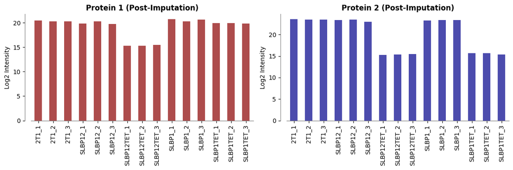

```python
# Verify imputation preserved biological signal
fig, axes = plt.subplots(ncols=2, figsize=(12, 4))

data_normalized_imputed.loc['Tb927.3.870:mRNA-p1'].plot(
    kind='bar', ax=axes[0], color='darkred', alpha=0.7
)
axes[0].set_title('Protein 1 (Post-Imputation)', fontweight='bold')
axes[0].set_ylabel('Log2 Intensity')
clean_axes(axes[0])

data_normalized_imputed.loc['Tb927.3.1910:mRNA-p1'].plot(
    kind='bar', ax=axes[1], color='darkblue', alpha=0.7
)
axes[1].set_title('Protein 2 (Post-Imputation)', fontweight='bold')
axes[1].set_ylabel('Log2 Intensity')
clean_axes(axes[1])

plt.tight_layout()
plt.show()
```

**Validated!** Imputation preserved our knockdown signals perfectly. Ready for statistical analysis!

# Differential Expression Analysis

Time for the main event! We'll use **limma** to identify differentially expressed proteins.

**Strategy:** Generate all pairwise comparisons, then select the most biologically relevant contrasts. This exploratory approach helps uncover unexpected patterns.

```python
# Create output directory
!mkdir -p table_comparisons_diaNN
```

```python
%%R -i data_normalized_imputed
options(warn = -1)
library(limma)

# Define experimental groups
f <- factor(
    c('T1', 'T1', 'T1',
      'S12', 'S12', 'S12',
      'S12T', 'S12T', 'S12T',
      'S1', 'S1', 'S1',
      'S1T', 'S1T', 'S1T'),
    levels = c("T1", "S12", "S12T", "S1", "S1T")
)

# Create design matrix
design <- model.matrix(~0 + f)
colnames(design) <- c("T1", "S12", "S12T", "S1", "S1T")

# Fit linear model
fit2 <- lmFit(data_normalized_imputed, design)

# Generate all pairwise contrasts
contrast_names <- list()
for (i in 1:length(levels(f))) {
    for (j in 1:length(levels(f))) {
        if (i != j) {
            contrast_name <- paste(levels(f)[i], "-", levels(f)[j], sep = "")
            contrast_names[[length(contrast_names) + 1]] <- contrast_name
        }
    }
}

contrast_vector <- unlist(contrast_names)
contrast_matrix <- makeContrasts(contrasts = contrast_vector, levels = design)

# Apply contrasts and empirical Bayes moderation
fit2 <- contrasts.fit(fit2, contrast_matrix)
fit2 <- eBayes(fit2)

# Export all comparison results
export_results <- function(fit, contrast_index, name) {
    results <- topTable(fit, coef = contrast_index, sort.by = "none", number = Inf)
    write.csv(results, paste0('table_comparisons_diaNN/', name, "_comparison.csv"))
}

for (idx in 1:length(colnames(contrast_matrix))) {
    contrast_name <- colnames(contrast_matrix)[idx]
    export_results(fit2, idx, contrast_name)
}

cat("✓ Generated", length(contrast_vector), "pairwise comparisons\n")
```

```
✓ Generated 20 pairwise comparisons
```

## Volcano Plots: Visualizing Differential Expression

Let's examine one key comparison and track our knockdown targets through the analysis.

```python
# Focus on a biologically relevant comparison
comparison_name = 'S12-S12T'
comparison_file = f'table_comparisons_diaNN/{comparison_name}_comparison.csv'
print(f"Analyzing: {comparison_name}")
```

```
Analyzing: S12-S12T
```

```python
# Track our knockdown targets
target_proteins = ['Tb927.3.870:mRNA-p1', 'Tb927.3.1910:mRNA-p1']
```

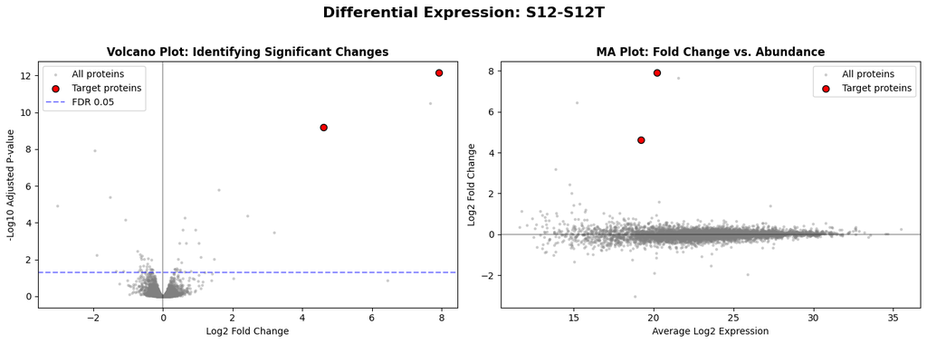

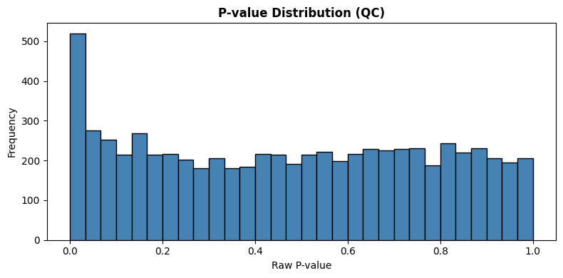

```python
# Generate volcano and MA plots
result_table = pd.read_csv(comparison_file, index_col=0)

# Calculate -log10 p-values for visualization
result_table['log10pval'] = -np.log10(result_table['P.Value'])
result_table['log10adjpval'] = -np.log10(result_table['adj.P.Val'])

fig, axes = plt.subplots(figsize=(14, 5), ncols=2)

# Volcano plot
ax = axes[0]
result_table.plot(
    x='logFC', y='log10adjpval',
    kind='scatter', s=5, alpha=0.3,
    ax=ax, c='gray', label='All proteins'
)
result_table.loc[target_proteins].plot(
    x='logFC', y='log10adjpval',
    kind='scatter', s=50, alpha=1,
    ax=ax, c='red', label='Target proteins', edgecolors='black'
)
ax.axhline(y=-np.log10(0.05), color='blue', linestyle='--', alpha=0.5, label='FDR 0.05')
ax.axvline(x=0, color='black', linestyle='-', alpha=0.3)
ax.set_title('Volcano Plot: Identifying Significant Changes', fontweight='bold')
ax.set_xlabel('Log2 Fold Change')
ax.set_ylabel('-Log10 Adjusted P-value')
ax.legend()

# MA plot
ax = axes[1]
result_table.plot(
    x='AveExpr', y='logFC',
    kind='scatter', s=5, alpha=0.3,
    ax=ax, c='gray', label='All proteins'
)
result_table.loc[target_proteins].plot(
    x='AveExpr', y='logFC',
    kind='scatter', s=50, alpha=1,
    ax=ax, c='red', label='Target proteins', edgecolors='black'
)
ax.axhline(y=0, color='black', linestyle='-', alpha=0.3)
ax.set_title('MA Plot: Fold Change vs. Abundance', fontweight='bold')
ax.set_xlabel('Average Log2 Expression')
ax.set_ylabel('Log2 Fold Change')
ax.legend()

plt.suptitle(f'Differential Expression: {comparison_name}', fontsize=16, fontweight='bold', y=1.02)
plt.tight_layout()
plt.show()

# P-value distribution (QC check)
fig, ax = plt.subplots(figsize=(8, 4))
result_table['P.Value'].plot(kind='hist', bins=30, ax=ax, color='steelblue', edgecolor='black')
ax.set_title('P-value Distribution (QC)', fontweight='bold')
ax.set_xlabel('Raw P-value')
ax.set_ylabel('Frequency')
plt.tight_layout()
plt.show()
```

# Interactive Visualization with PlotHub

Static plots are informative, but **interactive exploration** takes analysis to the next level!

We'll prepare our data for [PlotHub](https://plothub.pages.dev/) - enabling:

- Dynamic filtering and selection
- Hover-over protein annotations
- Linked views across multiple plots
- Easy sharing with collaborators

```python
# Export normalized data for PlotHub
data_normalized_imputed.to_csv('table_comparisons_diaNN/in_data.csv')
```

```python
# Load protein annotations from FASTA
prot_to_desc = parse_fasta_file('TriTrypDB-68_TbruceiTREU927_AnnotatedProteins.fasta')
!mkdir -p table_comparisons_PlotHub
```

```python
# Define sample group mappings
sample_to_columns = {
    'T1': ['2T1_1', '2T1_2', '2T1_3'],
    'S12': ['SLBP12_1', 'SLBP12_2', 'SLBP12_3'],
    'S12T': ['SLBP12TET_1', 'SLBP12TET_2', 'SLBP12TET_3'],
    'S1': ['SLBP1_1', 'SLBP1_2', 'SLBP1_3'],
    'S1T': ['SLBP1TET_1', 'SLBP1TET_2', 'SLBP1TET_3']
}

def prepare_for_plothub(data_df, comparison_df, data_cols):
    """
    Format data for PlotHub compatibility:
    - Add gene IDs and accessions
    - Calculate significance metrics
    - Append raw intensity values
    - Include protein descriptions
    """
    result = comparison_df.copy()

    # Format identifiers
    result['Gene_acc'] = range(result.shape[0])
    result['Gene_id'] = result.index.str.replace(':mRNA-p1', '', regex=False)

    # Prepare metrics
    result['log_AveExpr'] = result['AveExpr']
    result['FDR'] = -np.log10(result['adj.P.Val'])

    # Select core columns
    result = result[['Gene_acc', 'Gene_id', 'logFC', 'log_AveExpr', 'FDR']]

    # Add descriptions
    result['Desc'] = add_desc(data_df, prot_to_desc)

    # Append intensity values for the relevant samples
    intensity_data = data_df[data_cols].copy()
    result = result.join(intensity_data)
    result = result.reset_index(drop=True)

    return result

# Process all comparisons
print("Preparing PlotHub-compatible files...\n")
comparison_files = [f for f in os.listdir('table_comparisons_diaNN') if f.endswith('_comparison.csv')]

for file_name in comparison_files:
    # Load data
    data_df = pd.read_csv('table_comparisons_diaNN/in_data.csv', index_col=0)
    comparison_df = pd.read_csv(f'table_comparisons_diaNN/{file_name}', index_col=0)

    # Extract comparison name and get relevant columns
    comparison = file_name.replace('_comparison.csv', '')
    group1, group2 = comparison.split('-')
    data_cols = sample_to_columns[group1] + sample_to_columns[group2]

    # Format and save
    formatted = prepare_for_plothub(data_df, comparison_df, data_cols)
    output_path = f'table_comparisons_PlotHub/for_web_limma_{comparison}.csv'
    formatted.to_csv(output_path, index=False)

    print(f"✓ {comparison}: {formatted.shape[0]} proteins, {len(data_cols)} samples")

print(f"\n✓ All {len(comparison_files)} comparisons ready for PlotHub!")
```

```
Preparing PlotHub-compatible files...

✓ T1-S1: 6790 proteins, 6 samples
✓ S1-S12T: 6790 proteins, 6 samples
✓ S12T-S12: 6790 proteins, 6 samples
✓ S12T-S1T: 6790 proteins, 6 samples
✓ S1T-S12T: 6790 proteins, 6 samples
✓ S12-S12T: 6790 proteins, 6 samples
✓ S1-S12: 6790 proteins, 6 samples
✓ T1-S12T: 6790 proteins, 6 samples
✓ T1-S1T: 6790 proteins, 6 samples
✓ S12-S1T: 6790 proteins, 6 samples
✓ S1-S1T: 6790 proteins, 6 samples
✓ S1-T1: 6790 proteins, 6 samples
✓ T1-S12: 6790 proteins, 6 samples
✓ S12-S1: 6790 proteins, 6 samples
✓ S12T-S1: 6790 proteins, 6 samples
✓ S1T-S1: 6790 proteins, 6 samples
✓ S1T-T1: 6790 proteins, 6 samples
✓ S12T-T1: 6790 proteins, 6 samples
✓ S12-T1: 6790 proteins, 6 samples
✓ S1T-S12: 6790 proteins, 6 samples

✓ All 20 comparisons ready for PlotHub!
```

# Analysis Complete!

## What We Accomplished:

✓ **Data QC**: Identified and explained sample outliers  
✓ **Validation**: Confirmed knockdown efficiency and marker expression  
✓ **Normalization**: Balanced intensity distributions across samples  
✓ **Imputation**: Applied sophisticated missing data handling  
✓ **Statistics**: Performed comprehensive differential expression analysis  
✓ **Visualization**: Created publication-quality static and interactive plots

## Next Steps:

- Upload HTML to your web server
- See this output in [PlotHub](https://plothub.pages.dev/), by clicking on "Upload Test File".

*Analysis performed with custom utilities from the Delightful Data Analysis framework*